# statRregression_IA-M1DA2

Hady COULIBALY

2024-09-29

```r
#install.packages("corrplot")
#install.packages("caTools")
#install.packages("AER")
#install.packages("forecast")
#install.packages("mgcv")
#install.packages("ggplot2")
#install.packages("dplyr")
#install.packages("car")
```

```r
data_day = read.table("C:/Users/Hady COULIBALY/Desktop/M1-DA/Regression/Projet/day.csv", sep = ",", header = TRUE)
```

```r
data_hour = read.table("C:/Users/Hady COULIBALY/Desktop/M1-DA/Regression/Projet/hour.csv", sep = ",", header = TRUE)
```

```r
str(data_day)
```

```
## 'data.frame':    731 obs. of  16 variables:
##  $ instant   : int  1 2 3 4 5 6 7 8 9 10 ...
##  $ dteday    : chr  "2011-01-01" "2011-01-02" "2011-01-03" "2011-01-04" ...
##  $ season    : int  1 1 1 1 1 1 1 1 1 1 ...
##  $ yr        : int  0 0 0 0 0 0 0 0 0 0 ...
##  $ mnth      : int  1 1 1 1 1 1 1 1 1 1 ...
##  $ holiday   : int  0 0 0 0 0 0 0 0 0 0 ...
##  $ weekday   : int  6 0 1 2 3 4 5 6 0 1 ...
##  $ workingday: int  0 0 1 1 1 1 1 0 0 1 ...
##  $ weathersit: int  2 2 1 1 1 1 2 2 1 1 ...
##  $ temp      : num  0.344 0.363 0.196 0.2 0.227 ...
##  $ atemp     : num  0.364 0.354 0.189 0.212 0.229 ...
##  $ hum       : num  0.806 0.696 0.437 0.59 0.437 ...
##  $ windspeed : num  0.16 0.249 0.248 0.16 0.187 ...
##  $ casual    : int  331 131 120 108 82 88 148 68 54 41 ...
##  $ registered: int  654 670 1229 1454 1518 1518 1362 891 768 1280 ...
##  $ cnt       : int  985 801 1349 1562 1600 1606 1510 959 822 1321 ...
```

```r
str(data_hour)
```

```
## 'data.frame':    17379 obs. of  17 variables:
##  $ instant   : int  1 2 3 4 5 6 7 8 9 10 ...
##  $ dteday    : chr  "2011-01-01" "2011-01-01" "2011-01-01" "2011-01-01" ...
##  $ season    : int  1 1 1 1 1 1 1 1 1 1 ...
##  $ yr        : int  0 0 0 0 0 0 0 0 0 0 ...
##  $ mnth      : int  1 1 1 1 1 1 1 1 1 1 ...
##  $ hr        : int  0 1 2 3 4 5 6 7 8 9 ...
##  $ holiday   : int  0 0 0 0 0 0 0 0 0 0 ...
##  $ weekday   : int  6 6 6 6 6 6 6 6 6 6 ...
##  $ workingday: int  0 0 0 0 0 0 0 0 0 0 ...
##  $ weathersit: int  1 1 1 1 1 2 1 1 1 1 ...
##  $ temp      : num  0.24 0.22 0.22 0.24 0.24 0.24 0.22 0.2 0.24 0.32 ...
##  $ atemp     : num  0.288 0.273 0.273 0.288 0.288 ...
##  $ hum       : num  0.81 0.8 0.8 0.75 0.75 0.75 0.8 0.86 0.75 0.76 ...
##  $ windspeed : num  0 0 0 0 0 0.0896 0 0 0 0 ...
##  $ casual    : int  3 8 5 3 0 0 2 1 1 8 ...
##  $ registered: int  13 32 27 10 1 1 0 2 7 6 ...
##  $ cnt       : int  16 40 32 13 1 1 2 3 8 14 ...
```

# Prétraitement des données

```r
# Valeur manquante
sum(is.na(data_day))
```

```
## [1] 0
```

```r
colSums(is.na(data_day))
```

```
##    instant     dteday     season         yr       mnth    holiday    weekday
##          0          0          0          0          0          0          0
## workingday weathersit       temp      atemp        hum  windspeed     casual
##          0          0          0          0          0          0          0
## registered        cnt
##          0          0
```

### Transformation des variables

```r
data_day$dteday = as.Date(data_day$dteday)
data_hour$dteday = as.Date(data_hour$dteday)
data_hour$hr = factor(data_hour$hr, levels = 0:23)
data_day$season = factor(data_day$season,
                           levels = c(1, 2, 3, 4),
                           labels = c("Printemps", "Été", "Automne", "Hiver"))

data_day$mnth = factor(data_day$mnth,
                         levels = 1:12,
                         labels = month.name)

data_day$weekday = factor(data_day$weekday,
                            levels = 0:6,
                            labels = c("Dimanche", "Lundi", "Mardi", "Mercredi",
                                       "Jeudi", "Vendredi", "Samedi"))

data_day$weathersit = factor(data_day$weathersit,
                               levels = c(1, 2, 3, 4),
                               labels = c("Ciel dégagé", "Brouillard", "Pluie légère", "Fortes précipitations"))

data_day$holiday = factor(data_day$holiday,
                            levels = c(0, 1),
                            labels = c("Non", "Oui"))

data_day$workingday = factor(data_day$workingday,
                               levels = c(0, 1),
                               labels = c("Non", "Oui"))

str(data_day)
```

```
## 'data.frame':    731 obs. of  16 variables:
##  $ instant   : int  1 2 3 4 5 6 7 8 9 10 ...
##  $ dteday    : Date, format: "2011-01-01" "2011-01-02" ...
##  $ season    : Factor w/ 4 levels "Printemps","Été",..: 1 1 1 1 1 1 1 1 1 1 ...
##  $ yr        : int  0 0 0 0 0 0 0 0 0 0 ...
##  $ mnth      : Factor w/ 12 levels "January","February",..: 1 1 1 1 1 1 1 1 1 1 ...
##  $ holiday   : Factor w/ 2 levels "Non","Oui": 1 1 1 1 1 1 1 1 1 1 ...
##  $ weekday   : Factor w/ 7 levels "Dimanche","Lundi",..: 7 1 2 3 4 5 6 7 1 2 ...
##  $ workingday: Factor w/ 2 levels "Non","Oui": 1 1 2 2 2 2 2 1 1 2 ...
##  $ weathersit: Factor w/ 4 levels "Ciel dégagé",..: 2 2 1 1 1 1 2 2 1 1 ...
##  $ temp      : num  0.344 0.363 0.196 0.2 0.227 ...
##  $ atemp     : num  0.364 0.354 0.189 0.212 0.229 ...
##  $ hum       : num  0.806 0.696 0.437 0.59 0.437 ...
##  $ windspeed : num  0.16 0.249 0.248 0.16 0.187 ...
##  $ casual    : int  331 131 120 108 82 88 148 68 54 41 ...
##  $ registered: int  654 670 1229 1454 1518 1518 1362 891 768 1280 ...
##  $ cnt       : int  985 801 1349 1562 1600 1606 1510 959 822 1321 ...
```

# Partie 1: Analyse exploratoire des données

#### ○ Visualiser la distribution du nombre de locations de vélos par heure

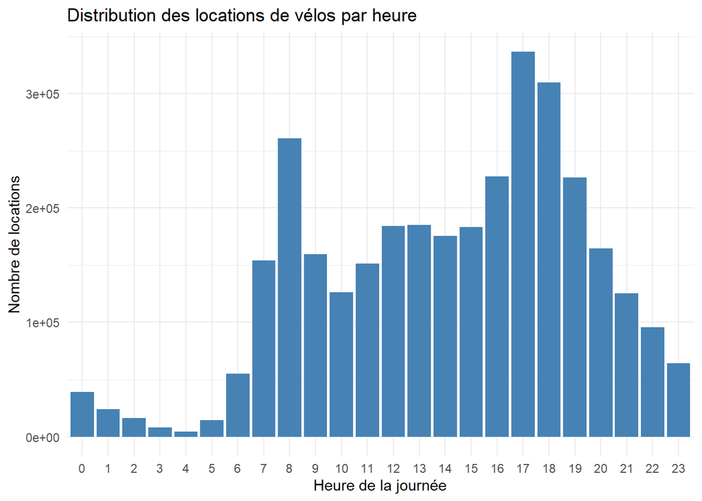

```r
library(ggplot2)
library(dplyr)
ggplot(data_hour, aes(x = hr, y = cnt)) +
  geom_histogram(stat = "identity", fill = "steelblue") +
  labs(title = "Distribution des locations de vélos par heure", x = "Heure de la journée", y = "Nombre de locations") +
  theme_minimal()
```

#### ○ Explorer les relations entre le nombre de locations et les différentes variables explicatives

```r
library(corrplot)
matrice_cor = cor(data_day[, c("cnt", "temp", "atemp", "hum", "windspeed", "casual","registered" )], use = "complete.obs")

print(matrice_cor)
```

```
##                   cnt       temp      atemp         hum  windspeed      casual
## cnt         1.0000000  0.6274940  0.6310657 -0.10065856 -0.2345450  0.67280443
## temp        0.6274940  1.0000000  0.9917016  0.12696294 -0.1579441  0.54328466
## atemp       0.6310657  0.9917016  1.0000000  0.13998806 -0.1836430  0.54386369
## hum        -0.1006586  0.1269629  0.1399881  1.00000000 -0.2484891 -0.07700788
## windspeed  -0.2345450 -0.1579441 -0.1836430 -0.24848910  1.0000000 -0.16761335
## casual      0.6728044  0.5432847  0.5438637 -0.07700788 -0.1676133  1.00000000
## registered  0.9455169  0.5400120  0.5441918 -0.09108860 -0.2174490  0.39528245
##            registered
## cnt         0.9455169
## temp        0.5400120
## atemp       0.5441918
## hum        -0.0910886
## windspeed  -0.2174490
## casual      0.3952825
## registered  1.0000000
```

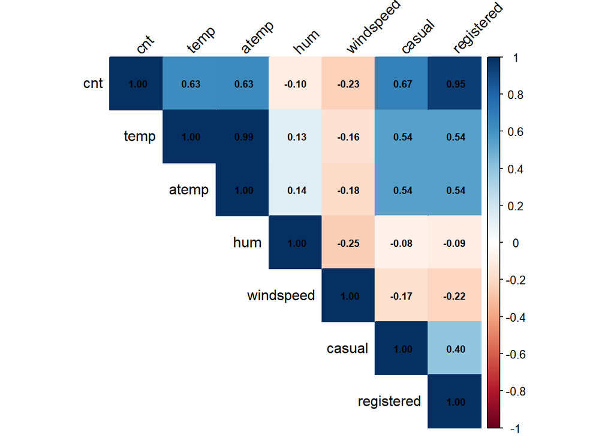

```r
library(corrplot)

corrplot(matrice_cor, method = "color", type = "upper",
         tl.col = "black", tl.srt = 45, addCoef.col = "black",
         number.cex = 0.7, number.digits = 2)
```

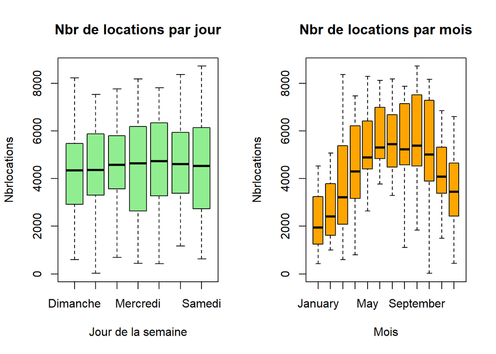

```r
par(mfcol = c(1,2))

boxplot(data_day$cnt ~ data_day$weekday, main= "Nbr de locations par jour",xlab=" Jour de la semaine ",ylab = "Nbrlocations", col= "lightgreen")

boxplot(data_day$cnt ~ data_day$mnth, main= "Nbr de locations par mois",xlab=" Mois ",ylab = "Nbrlocations", col= "orange")
```

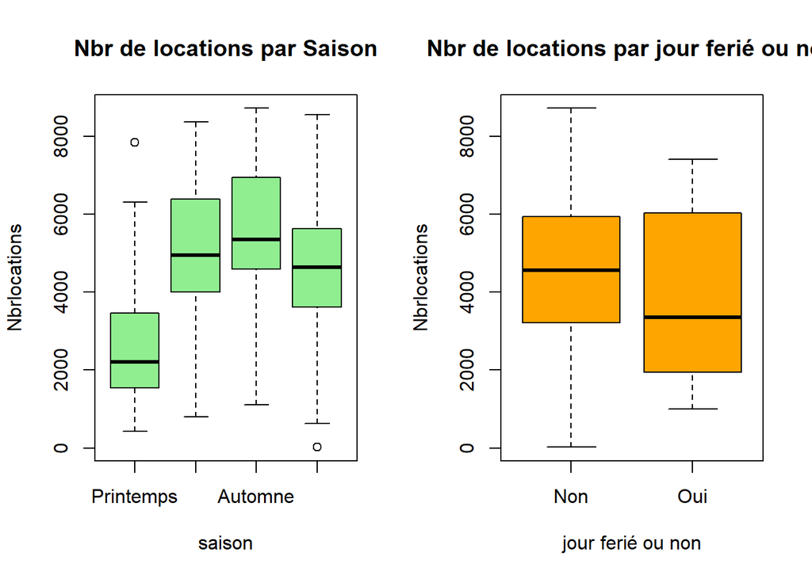

```r
par(mfcol = c(1,2))

boxplot(data_day$cnt ~ data_day$season, main= "Nbr de locations par Saison", xlab = "saison",ylab = "Nbrlocations", col="lightgreen")

boxplot(data_day$cnt ~ data_day$holiday, main= "Nbr de locations par jour ferié ou non",xlab=" jour ferié ou non ",ylab = "Nbrlocations", col= "orange")
```

#### ○ Identifier des tendances saisonnières ou temporelles

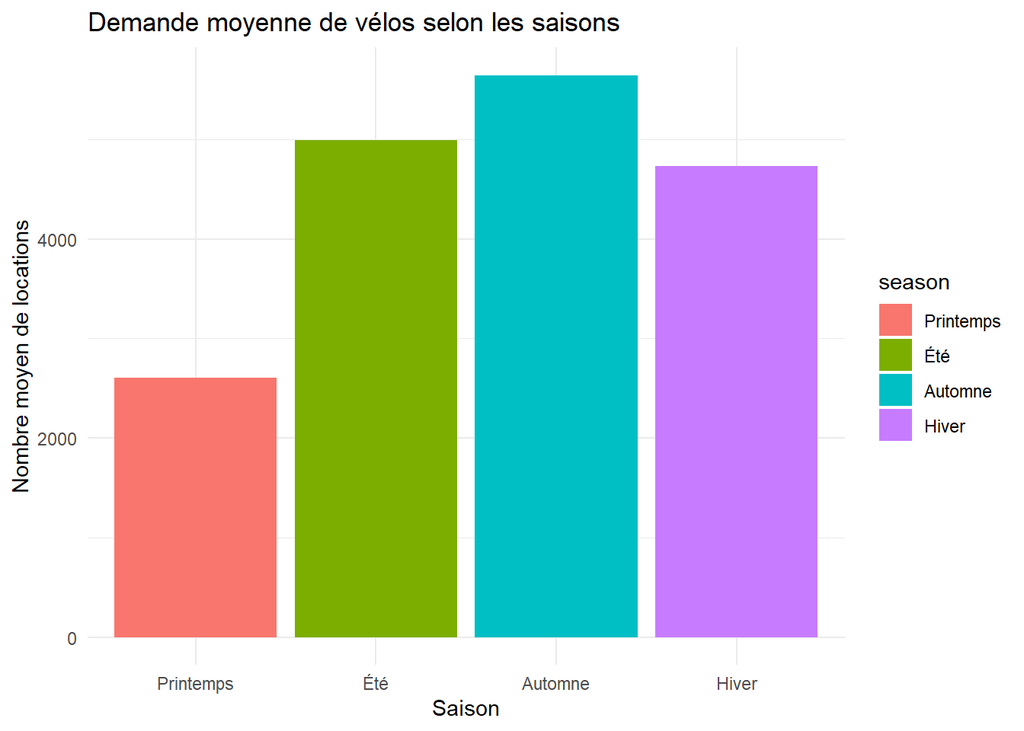

```r
library(ggplot2)
# Moyenne des locations par saison
seasonal_trends = data_day %>%
  group_by(season) %>%
  summarise(mean_cnt = mean(cnt, na.rm = TRUE))

# Visualisation de la demande moyenne par saison
ggplot(seasonal_trends, aes(x = season, y = mean_cnt, fill = season)) +
  geom_bar(stat = "identity") +
  labs(title = "Demande moyenne de vélos selon les saisons", x = "Saison", y = "Nombre moyen de locations") +
  theme_minimal()
```

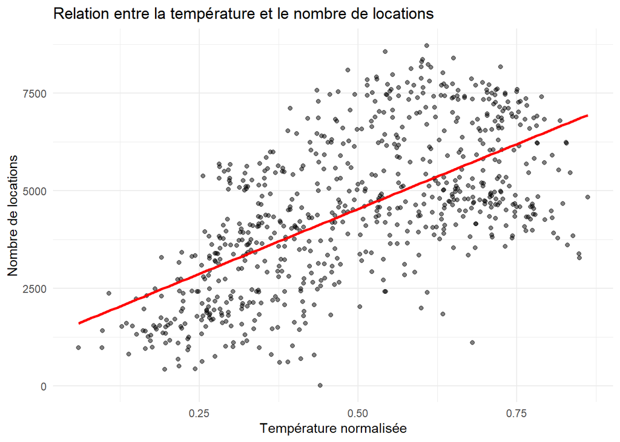

```r
# Relation entre le nombre de locations et la température
ggplot(data_day, aes(x=temp, y=cnt)) +
  geom_point(alpha=0.5) +
  geom_smooth(method="lm", se=FALSE, color="red") +
  labs(title="Relation entre la température et le nombre de locations", x="Température normalisée", y="Nombre de locations") +
  theme_minimal()
```

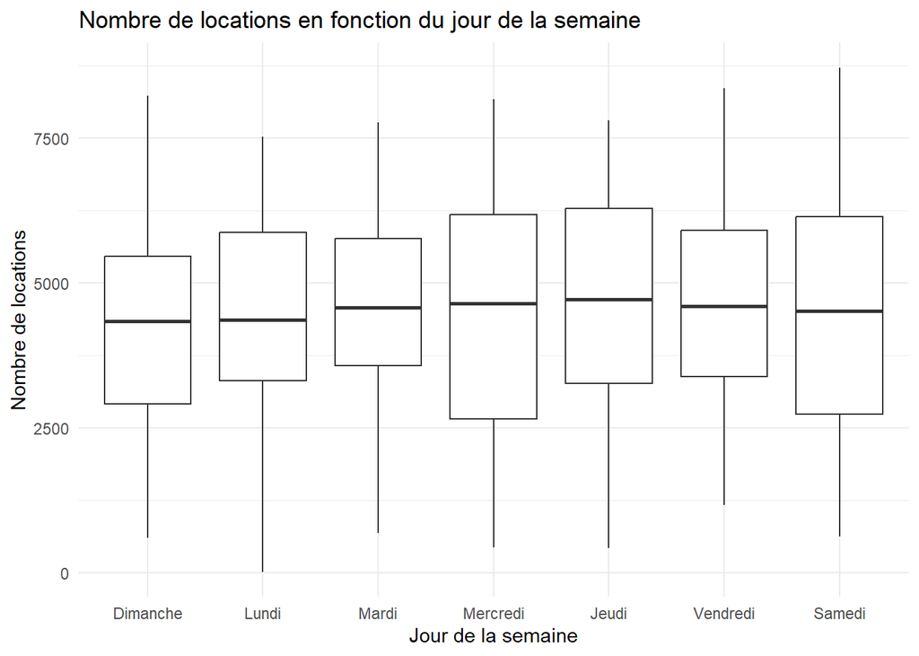

```r
# Relation entre le nombre de locations et le jour de la semaine
ggplot(data_day, aes(x=weekday, y=cnt)) +
  geom_boxplot(aes(group=weekday)) +
  labs(title="Nombre de locations en fonction du jour de la semaine", x="Jour de la semaine", y="Nombre de locations") +
  theme_minimal()
```

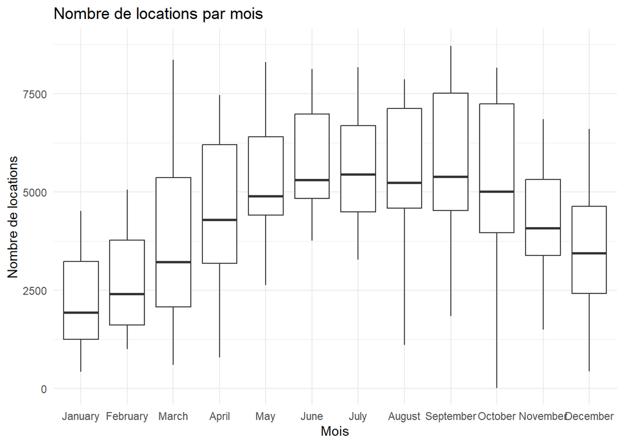

```r
# Nombre de locations par mois
ggplot(data_day, aes(x=mnth, y=cnt)) +
  geom_boxplot(aes(group=mnth)) +
  labs(title="Nombre de locations par mois", x="Mois", y="Nombre de locations") +
  theme_minimal()
```

# Partie 2: Modélisation

Le projet vise à modéliser la demande de vélos en libre-service en fonction de plusieurs variables explicatives comme la météo, le jour de la semaine, la saison, etc. Le nombre de locations de vélos est une variable de comptage (une variable entière non négative) et demande une approche spécifique pour sa modélisation.

Dans le cadre de cette étude, ce n’est pas pertinent d’utiliser le modèle de regression linéaire pour la réduction car elle suppose que la variable dépendante suit une distribution normale et que les résidus sont également normalement distribués, ce qui n’est pas adapté pour une variable de comptage non négative comme le nombre de locations (cnt).

Les modèles les plus appropriés pour des données de comptage sont:

1. Régression de Poisson
2. Régression binomiale négative
3. GAM (Generalized Additive Model)
4. Modèles temporels (SARIMA)

###### Diviser le jeu de donnée en ensembles de donnée d’entraînement et de test

```r
#install.packages("caTools")
library(caTools)
```

```r
set.seed(123)

# Diviser les données en 80% pour l'entraînement et 20% pour le test
split = sample.split(data_day$cnt, SplitRatio = 0.8)

# Créer les ensembles d'entraînement et de test
train_data = subset(data_day, split == TRUE)
test_data = subset(data_day, split == FALSE)
```

### Modèle de Poisson de base

```r
poisson_model = glm(cnt ~ temp + atemp + hum + windspeed + season + yr + mnth + weekday + holiday ,
                     data = train_data, family = poisson(link = "log"))
summary(poisson_model)
```

```
##
## Call:
## glm(formula = cnt ~ temp + atemp + hum + windspeed + season +
##     yr + mnth + weekday + holiday, family = poisson(link = "log"),
##     data = train_data)
##
## Deviance Residuals:
##     Min       1Q   Median       3Q      Max
## -91.960   -7.189    1.306    8.225   39.142
##
## Coefficients:
##                  Estimate Std. Error  z value Pr(>|z|)
## (Intercept)      7.600663   0.005705 1332.194  < 2e-16 ***
## temp             0.731190   0.027267   26.816  < 2e-16 ***
## atemp            0.867955   0.028539   30.413  < 2e-16 ***
## hum             -0.725171   0.005200 -139.455  < 2e-16 ***
## windspeed       -0.837333   0.009291  -90.122  < 2e-16 ***
## seasonÉté        0.256019   0.004062   63.027  < 2e-16 ***
## seasonAutomne    0.249351   0.004752   52.468  < 2e-16 ***
## seasonHiver      0.469558   0.004624  101.539  < 2e-16 ***
## yr               0.450937   0.001295  348.199  < 2e-16 ***
## mnthFebruary     0.088257   0.004167   21.181  < 2e-16 ***
## mnthMarch        0.181797   0.004428   41.052  < 2e-16 ***
## mnthApril        0.086404   0.005881   14.692  < 2e-16 ***
## mnthMay          0.134837   0.006200   21.747  < 2e-16 ***
## mnthJune         0.027016   0.006498    4.158 3.21e-05 ***
## mnthJuly        -0.108016   0.007122  -15.166  < 2e-16 ***
## mnthAugust       0.010111   0.006861    1.474    0.141
## mnthSeptember    0.127631   0.006276   20.338  < 2e-16 ***
## mnthOctober      0.039000   0.006133    6.359 2.03e-10 ***
## mnthNovember     0.003737   0.005958    0.627    0.530
## mnthDecember     0.002030   0.005286    0.384    0.701
## weekdayLundi     0.056595   0.002446   23.139  < 2e-16 ***
## weekdayMardi     0.049037   0.002436   20.128  < 2e-16 ***
## weekdayMercredi  0.045383   0.002436   18.629  < 2e-16 ***
## weekdayJeudi     0.039517   0.002448   16.144  < 2e-16 ***
## weekdayVendredi  0.087326   0.002332   37.454  < 2e-16 ***
## weekdaySamedi    0.082274   0.002407   34.185  < 2e-16 ***
## holidayOui      -0.152520   0.004089  -37.305  < 2e-16 ***
## ---
## Signif. codes:  0 '***' 0.001 '**' 0.01 '*' 0.05 '.' 0.1 ' ' 1
##
## (Dispersion parameter for poisson family taken to be 1)
##
##     Null deviance: 525107  on 583  degrees of freedom
## Residual deviance: 111472  on 557  degrees of freedom
## AIC: 117434
##
## Number of Fisher Scoring iterations: 4
```

```r
# Verification de la dispersion avec la fonction dispersiontest()
library(AER)
# Test de surdispersion
dispersiontest(poisson_model)
```

```
##
##  Overdispersion test
##
## data:  poisson_model
## z = 12.227, p-value < 2.2e-16
## alternative hypothesis: true dispersion is greater than 1
## sample estimates:
## dispersion
##   169.9312
```

```r
# Vérification de la distribution  avec le ratio variance/moyenne
mean_cnt = mean(data_day$cnt)
var_cnt = var(data_day$cnt)

mean_cnt  # Moyenne
```

```
## [1] 4504.349
```

```r
var_cnt   # Variance
```

```
## [1] 3752788
```

```r
# Vérification du ratio variance / moyenne
var_cnt / mean_cnt
```

```
## [1] 833.1478
```

### Modèle binomial négatif

Si les données montrent de la surdispersion (la variance est plus grande que la moyenne), la régression binomiale négative est plus adaptée.Nous avons dejà verifier cette surdispersion à l’aide du Test de dispersion et de la ratio de variance/moyenne ci-dessus.

Nous pouvons maintenant ajuster notre modèle sur l’ensemble des données d’entraînement :

```r
library(dplyr)
#install.packages("MASS")
#install.packages("MASS", repos = "http://cran.us.r-project.org")

library(MASS)
# Ajuster le modèle binomial négatif sur l'ensemble d'entraînement
nb_model_train = glm.nb(cnt ~  + atemp + hum + windspeed + season + yr + mnth + weekday + holiday,
                         data = train_data)
```

```r
summary(nb_model_train)
```

```
##
## Call:
## glm.nb(formula = cnt ~ +atemp + hum + windspeed + season + yr +
##     mnth + weekday + holiday, data = train_data, init.theta = 14.73619871,
##     link = log)
##
## Deviance Residuals:
##      Min        1Q    Median        3Q       Max
## -10.8490   -0.4434    0.0885    0.4823    3.2190
##
## Coefficients:
##                 Estimate Std. Error z value Pr(>|z|)
## (Intercept)      7.49576    0.08661  86.547  < 2e-16 ***
## atemp            1.94819    0.15832  12.305  < 2e-16 ***
## hum             -0.83266    0.08645  -9.632  < 2e-16 ***
## windspeed       -0.88981    0.15352  -5.796 6.79e-09 ***
## seasonÉté        0.22991    0.06806   3.378 0.000730 ***
## seasonAutomne    0.27758    0.08205   3.383 0.000717 ***
## seasonHiver      0.53849    0.06939   7.761 8.46e-15 ***
## yr               0.47903    0.02208  21.693  < 2e-16 ***
## mnthFebruary     0.10269    0.05424   1.893 0.058333 .
## mnthMarch        0.18791    0.06253   3.005 0.002654 **
## mnthApril        0.11026    0.09276   1.189 0.234560
## mnthMay          0.17966    0.09856   1.823 0.068326 .
## mnthJune         0.03262    0.10267   0.318 0.750684
## mnthJuly        -0.15031    0.11657  -1.290 0.197223
## mnthAugust      -0.02434    0.11141  -0.218 0.827057
## mnthSeptember    0.08521    0.10001   0.852 0.394181
## mnthOctober     -0.03182    0.09160  -0.347 0.728311
## mnthNovember    -0.03332    0.08803  -0.378 0.705107
## mnthDecember    -0.02096    0.07040  -0.298 0.765919
## weekdayLundi     0.06812    0.04164   1.636 0.101897
## weekdayMardi     0.05273    0.04170   1.264 0.206100
## weekdayMercredi  0.05257    0.04146   1.268 0.204804
## weekdayJeudi     0.04428    0.04197   1.055 0.291329
## weekdayVendredi  0.11836    0.03985   2.970 0.002981 **
## weekdaySamedi    0.07034    0.04095   1.718 0.085819 .
## holidayOui      -0.17868    0.06568  -2.720 0.006524 **
## ---
## Signif. codes:  0 '***' 0.001 '**' 0.01 '*' 0.05 '.' 0.1 ' ' 1
##
## (Dispersion parameter for Negative Binomial(14.7362) family taken to be 1)
##
##     Null deviance: 2202.75  on 583  degrees of freedom
## Residual deviance:  597.54  on 558  degrees of freedom
## AIC: 9832.8
##
## Number of Fisher Scoring iterations: 1
##
##
##               Theta:  14.736
##           Std. Err.:  0.866
##
##  2 x log-likelihood:  -9778.804
```

### Modèle GAM (Generalized Additive Model)

Ce modèle permet de capturer des relations non linéaires à l’aide de splines. Si des relations non linéaires sont présentes entre la variable de réponse et les prédicteurs, ce modèle devient pertinent.

```r
library(mgcv)
# Modèle GAM pour capturer des relations non linéaires
gam_model = gam(cnt ~ s(temp) + s(hum) + s(windspeed) + season + yr + mnth + weekday + holiday + workingday,
                 data = train_data, family = poisson(link = "log"))
summary(gam_model)
```

```
##
## Family: poisson
## Link function: log
##
## Formula:
## cnt ~ s(temp) + s(hum) + s(windspeed) + season + yr + mnth +
##     weekday + holiday + workingday
##
## Parametric coefficients:
##                  Estimate Std. Error  z value Pr(>|z|)
## (Intercept)      7.896573   0.004388 1799.615  < 2e-16 ***
## seasonÉté        0.241967   0.004153   58.258  < 2e-16 ***
## seasonAutomne    0.310683   0.004999   62.146  < 2e-16 ***
## seasonHiver      0.470012   0.004822   97.476  < 2e-16 ***
## yr               0.421723   0.001333  316.262  < 2e-16 ***
## mnthFebruary    -0.019752   0.004360   -4.530 5.89e-06 ***
## mnthMarch        0.003551   0.004745    0.748    0.454
## mnthApril       -0.119994   0.006131  -19.572  < 2e-16 ***
## mnthMay         -0.083850   0.006459  -12.981  < 2e-16 ***
## mnthJune        -0.119726   0.006711  -17.840  < 2e-16 ***
## mnthJuly        -0.104540   0.007260  -14.399  < 2e-16 ***
## mnthAugust      -0.173700   0.007146  -24.307  < 2e-16 ***
## mnthSeptember   -0.105277   0.006706  -15.698  < 2e-16 ***
## mnthOctober     -0.211020   0.006491  -32.509  < 2e-16 ***
## mnthNovember    -0.166399   0.006269  -26.541  < 2e-16 ***
## mnthDecember    -0.096967   0.005609  -17.289  < 2e-16 ***
## weekdayLundi    -0.077825   0.004411  -17.643  < 2e-16 ***
## weekdayMardi    -0.075706   0.004808  -15.745  < 2e-16 ***
## weekdayMercredi -0.074544   0.004760  -15.660  < 2e-16 ***
## weekdayJeudi    -0.066216   0.004772  -13.877  < 2e-16 ***
## weekdayVendredi -0.031617   0.004747   -6.661 2.72e-11 ***
## weekdaySamedi    0.087150   0.002444   35.661  < 2e-16 ***
## holidayOui       0.000000   0.000000      NaN      NaN
## workingdayOui    0.121310   0.004159   29.171  < 2e-16 ***
## ---
## Signif. codes:  0 '***' 0.001 '**' 0.01 '*' 0.05 '.' 0.1 ' ' 1
##
## Approximate significance of smooth terms:
##                edf Ref.df Chi.sq p-value
## s(temp)      8.945  8.999  48898  <2e-16 ***
## s(hum)       8.983  9.000  33475  <2e-16 ***
## s(windspeed) 8.983  9.000  10820  <2e-16 ***
## ---
## Signif. codes:  0 '***' 0.001 '**' 0.01 '*' 0.05 '.' 0.1 ' ' 1
##
## Rank: 50/51
## R-sq.(adj) =  0.867   Deviance explained = 86.2%
## UBRE = 123.13  Scale est. = 1         n = 584
```

### Modèle ARIMA simple

Pour capturer des dépendances temporelles dans les données, un modèle SARIMA peut être utile, bien qu’il soit principalement utilisé dans des séries chronologiques pures.

```r
library(forecast)
sarima_model = auto.arima(data_day$cnt, seasonal = TRUE)
summary(sarima_model)
```

```
## Series: data_day$cnt
## ARIMA(1,1,1)
##
## Coefficients:
##          ar1      ma1
##       0.3584  -0.8896
## s.e.  0.0423   0.0192
##
## sigma^2 = 857769:  log likelihood = -6021.96
## AIC=12049.91   AICc=12049.94   BIC=12063.69
##
## Training set error measures:
##                    ME     RMSE      MAE       MPE     MAPE      MASE       ACF1
## Training set 12.87842 924.2558 647.6408 -44.46123 58.52916 0.8873291 0.01117124
```

### Comparaison des performances des différents modèles

```r
# Comparer les modèles avec le test du rapport de vraisemblance
lrtest = lmtest::lrtest(poisson_model, nb_model_train)

# Afficher les résultats du test du rapport de vraisemblance
lrtest
```

|  | #Df | LogLik | Df | Chisq | Pr(>Chisq) |
| --- | --- | --- | --- | --- | --- |
| 1 | 27 | -58690.005 | NA | NA | NA |
| 2 | 27 | -4889.402 | 0 | 107601.2 | 0 |

```r
# Comparer les modèles gam_model et nb_model_train avec le test du rapport de vraisemblance
lrtest = lmtest::lrtest(gam_model, nb_model_train)
# Afficher les résultats du test du rapport de vraisemblance
lrtest
```

|  | #Df | LogLik | Df | Chisq | Pr(>Chisq) |
| --- | --- | --- | --- | --- | --- |
| 1 | 49.91087 | -39150.418 | NA | NA | NA |
| 2 | 27.00000 | -4889.402 | -22.91087 | 68522.03 | 0 |

###### Verification de l’hyphothèse de multiconéarité

```r
library("car")
vif(nb_model_train)
```

```
##                 GVIF Df GVIF^(1/(2*Df))
## atemp       5.549442  1        2.355725
## hum         1.295027  1        1.137992
## windspeed   1.191248  1        1.091443
## season    184.483976  3        2.385941
## yr          1.044712  1        1.022112
## mnth      393.665620 11        1.312080
## weekday     1.167204  6        1.012968
## holiday     1.103549  1        1.050499
```

```r
# Prédictions sur l'ensemble de test
pred_test = predict(nb_model_train, newdata = test_data, type = "response")

# Comparer les prédictions avec les valeurs réelles (par exemple avec RMSE ou MAE)
rmse_test = sqrt(mean((pred_test - test_data$cnt)^2))
print(paste("RMSE sur l'ensemble de test:", rmse_test))
```

```
## [1] "RMSE sur l'ensemble de test: 1095.85096042065"
```

```r
mean(data_day$cnt)
```

```
## [1] 4504.349
```

# Partie 3: Prédictions et recommandations

###### Prédictions

Création d’un nouveau data frame pour la préduction

```r
new_data=data.frame(
  atemp = c(0.35, 0.25, 0.15),
  hum = c(0.6, 0.8, 0.4),
  windspeed = c(0.2, 0.3, 0.1),
  season = factor(c("Été", "Hiver", "Printemps"),
                  levels = c("Printemps", "Été", "Automne", "Hiver")),
  yr = c(1, 1, 0),
  mnth = factor(c(6, 1, 3),
                 levels = 1:12,
                 labels = month.name),
  weekday = factor(c("Lundi", "Mercredi", "Vendredi"),
                   levels = c("Dimanche", "Lundi", "Mardi", "Mercredi", "Jeudi", "Vendredi", "Samedi")),
  holiday = factor(c("Non", "Non", "Oui"),
                   levels = c("Non", "Oui"))

)
```

```r
# Préduction
predictions = predict(nb_model_train, newdata = new_data, type = "response")

print(predictions)
```

```
##        1        2        3
## 4063.286 3360.433 1796.387
```